# Metropolis traffic figures: schema-compatible simulated example

**These figures use simulated data, not the original Metropolis observations.** Unlike the Beijing and LargeST maps, the checked-in Metropolis HTML does not embed its observations. It references `city_traffic_M_osm_congestion_sample.js`, which is absent from this checkout. No matching companion data were found in local project copies or Git history. Consequently, the original city figures cannot currently be reproduced numerically.

This tutorial uses the agreed fallback: a seeded dataset with the same segment, frame and measurement fields. It reproduces the viewer’s two map styles and two whole-day trends through package functions. The original HTML is unchanged.

## Load standalone data

Install `bdynets` and `jsonlite`. Rendering also requires `rmarkdown` and `knitr`. Rendering loads the saved dataset; it does not resimulate, download or fit models.

```r
library(bdynets)
x <- read_traffic_data(params$dataset)
x$provenance
```

```
## $file
## [1] "metropolis-simulated.json.gz"
##
## $md5
## [1] "ec1dedec75514bcfe2e6b79e723a033c"
##
## $source_html
## [1] "unavailable companion data; simulated fallback"
##
## $representation
## [1] "SIMULATED schema-compatible data"
##
## $seed
## [1] 20261015
```

```r
x$data$metadata
```

```
## $title
## [1] "SIMULATED Metropolis-format example"
##
## $synthetic
## [1] TRUE
##
## $seed
## [1] 20261015
##
## $nativeTimeStepMinutes
## [1] 5
##
## $frameIntervalMinutes
## [1] 15
##
## $frameAggregation
## [1] "mean of three 5-minute observations"
##
## $sampleDay
## [1] "2026-01-01"
##
## $frameCount
## [1] 96
##
## $dynamicSegmentCount
## [1] 142
##
## $peakFrameIndex
## [1] 32
##
## $peakFrame
## [1] "2026-01-01 08:00"
##
## $volumeP95
## [1] 143.67
##
## $congestionP95
## [1] 0.455
##
## $congestionDefinition
## [1] "max(0, 1 - speed / segment_p90_speed) times clipped log-volume weight"
```

The example has a synthetic rectangular road layout and 96 fifteen-minute frames. The volume and speed frames average three simulated five-minute observations. Coordinates are artificial and do not identify the original city. Seed 20261015 fixes the example; the generator restores the caller’s RNG state.

Congestion follows the source construction: nonnegative slowdown relative to each segment’s 90th-percentile speed, multiplied by a clipped log-volume weight. The volume map instead normalizes volume by the sample’s 95th percentile. These are descriptive visualization metrics, not posterior model estimates.

## Reproduce both map modes and trend panels

The common workflow selects the frame with greatest total congestion, matching the source viewer’s selection rule. Maps use the green–amber–red interpolation, line-width scaling and dark road casing from the viewer. Trends use the saved aggregate values; a vertical marker shows the selected frame.

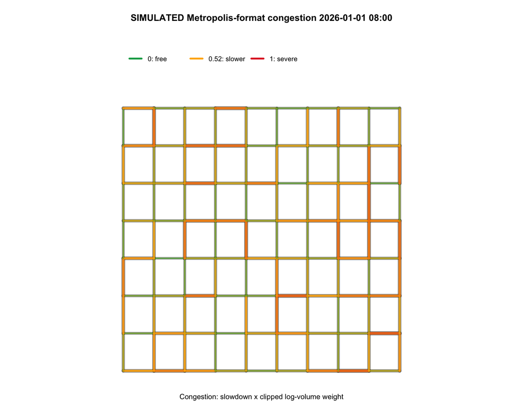

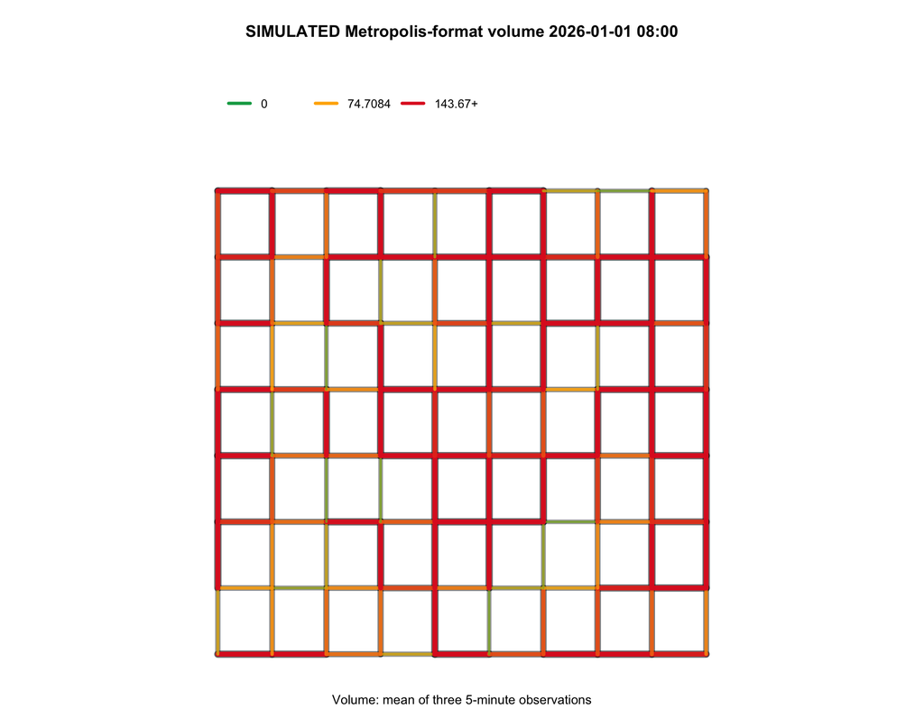

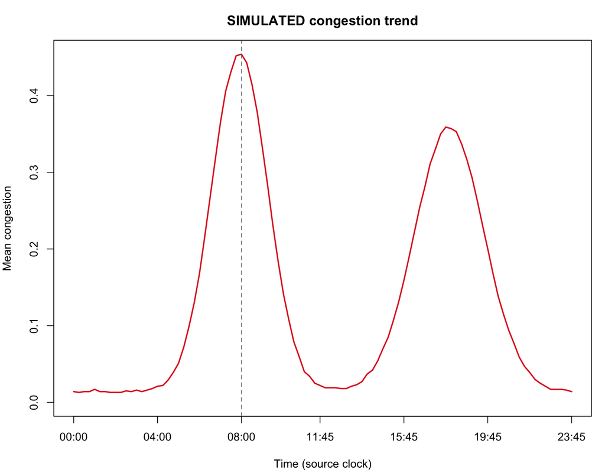

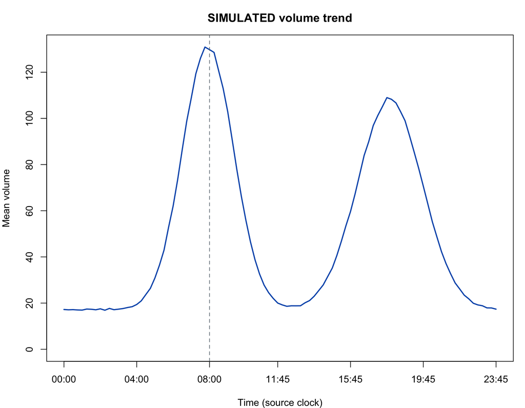

```r
figures <- traffic_figures(params$dataset, "metropolis")
```

Remote OpenStreetMap tiles, place labels and browser controls are omitted. The map geometry uses Web Mercator; line widths are adapted to the static device. Colors saturate at one for congestion and at the saved volume scale for volume. The different metric definitions mean the same color does not represent the same quantity between modes. The trend line is descriptive of this simulation only; it establishes nothing about real metropolitan traffic.

## Select a frame and export figures

```r
plot(traffic_frame(x, time_index=33L, metric="volume"))
plot(traffic_trend(x, metric="congestion", time_index=33L))
traffic_figures(params$dataset, "metropolis", time_index=33L,
                output_dir="/path/to/new/metropolis-figures")
```

The batch script calls the same workflow. Export produces four PDF/PNG figures, provenance and session information; existing output files are refused.

## Recreate the simulation or import the missing real payload

Simulation is a separate, explicit preparation step, not part of rendering:

```r
simulate_metropolis_data("/path/to/new/metropolis-simulated.json.gz", seed=20261015L)
```

**TODO for real-data reproduction:** restore the companion JavaScript file from the original visualization run. Then extract its JSON assignment without executing any JavaScript:

```r
extract_traffic_data("/path/to/city_traffic_M_osm_congestion_sample.js",
                     "metropolis", "/path/to/new/metropolis-real.json.gz")
real <- read_traffic_data("/path/to/new/metropolis-real.json.gz")
traffic_figures("/path/to/new/metropolis-real.json.gz", "metropolis")
```

The real payload uses the same plotting API. Do not rename the simulated file as real data or remove its simulation label. When making a real-data report, update the input and narrative to describe the actual source and provenance.

[session information not shown]